# Introduction to R

Introduction to R Objectives:

- Become familiar with the RStudio IDE, R syntax, and R data types
- Understand how to get help with R
- Become familiar with the R reference card
- Become familiar with Rmarkdown to generate reports

There are many software programs designed to store, summarize, visualize, or analyze data:

- Spreadsheets: Microsoft Excel, Google Sheets, etc.
- Data Analysis and Statistical programs: SAS, SPSS, Minitab
- Programming languages: Python, C, C++, Fortran, Java
- Database software: Microsoft Access, SAP, SQL databases

`R` is statistical software which can read data, manipulate data, summarize data, fit statistical models, create quality plots, and more. It is used by companies like Google, Twitter, and Microsoft, as well as in government agencies and at national labs.

# Setting Up

This guide will help set up R and RStudio on your machine. It is included for reference.

## Installing R

On Windows or OS X:

- Go to http://www.r-project.org/
- Click the CRAN link on the left, and pick a download site (0-Cloud is a good choice)
- Choose link based on your OS
- On Windows, choose the “base” subdirectory to install R.
- On OS X, choose the .pkg file to install R.

## Installing RStudio

- Browse to https://www.rstudio.com/
- Mouse over Products and click RStudio
- Choose RStudio Desktop
- Click Download RStudio Desktop
- Choose the installer appropriate for your platform

# Example: Tips data

## Goals

- Explore a real dataset using R
- Get the “flavor” of R for data management and exploration
- Don’t focus on the code - it will be explained later and in much more detail

## Tips Dataset

A server recorded the tips they received over about 10 weeks, including several variables:

- Amount they were tipped
- Cost of the total bill
- Characteristics about the party (# people, gender, etc.)

Primary Question: How do these variable influence the amount being tipped?

Follow along using Tips-Example.R

## First look: Reading in the data

Use R to look at the top few rows of the tips data set. First, load tip using `read.csv`:

```r
tips <- read.csv("http://bit.ly/2iNqvKM")
```

Now, use the `head` function to look at the first 6 rows of the data:

```r
head(tips)
##   total_bill  tip    sex smoker day   time size
## 1      16.99 1.01 Female     No Sun Dinner    2
## 2      10.34 1.66   Male     No Sun Dinner    3
## 3      21.01 3.50   Male     No Sun Dinner    3
## 4      23.68 3.31   Male     No Sun Dinner    2
## 5      24.59 3.61 Female     No Sun Dinner    4
## 6      25.29 4.71   Male     No Sun Dinner    4
```

How big is this data set and what types of variables are in each column?

```r
str(tips)
## 'data.frame':    244 obs. of  7 variables:
##  $ total_bill: num  17 10.3 21 23.7 24.6 ...
##  $ tip       : num  1.01 1.66 3.5 3.31 3.61 4.71 2 3.12 1.96 3.23 ...
##  $ sex       : Factor w/ 2 levels "Female","Male": 1 2 2 2 1 2 2 2 2 2 ...
##  $ smoker    : Factor w/ 2 levels "No","Yes": 1 1 1 1 1 1 1 1 1 1 ...
##  $ day       : Factor w/ 4 levels "Fri","Sat","Sun",..: 3 3 3 3 3 3 3 3 3 3 ...
##  $ time      : Factor w/ 2 levels "Dinner","Lunch": 1 1 1 1 1 1 1 1 1 1 ...
##  $ size      : int  2 3 3 2 4 4 2 4 2 2 ...
```

Get a summary of the values for each variable in tips:

```r
summary(tips)
##    total_bill         tip             sex      smoker      day
##  Min.   : 3.07   Min.   : 1.000   Female: 87   No :151   Fri :19
##  1st Qu.:13.35   1st Qu.: 2.000   Male  :157   Yes: 93   Sat :87
##  Median :17.80   Median : 2.900                          Sun :76
##  Mean   :19.79   Mean   : 2.998                          Thur:62
##  3rd Qu.:24.13   3rd Qu.: 3.562
##  Max.   :50.81   Max.   :10.000
##      time          size
##  Dinner:176   Min.   :1.00
##  Lunch : 68   1st Qu.:2.00
##               Median :2.00
##               Mean   :2.57
##               3rd Qu.:3.00
##               Max.   :6.00
```

What is the relationship between total bill and tip value? First, install and load `ggplot2` (a graphics library):

```r
install.packages("ggplot2")
library(ggplot2)
```

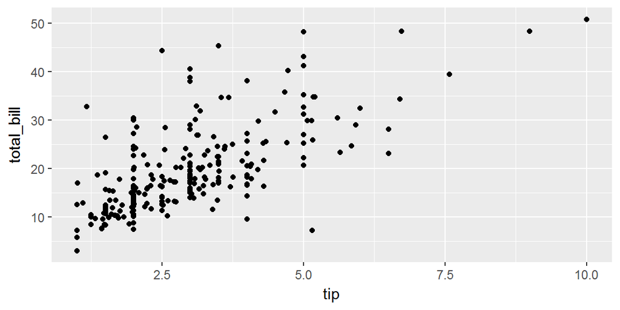

```r
qplot(x = tip, y = total_bill, geom = "point", data = tips)
```

Add linear regression line to the plot:

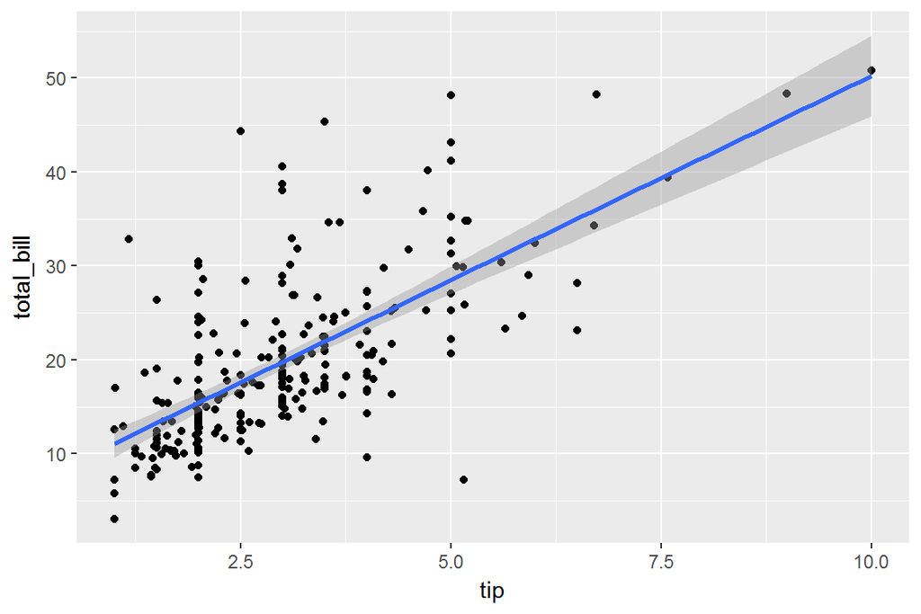

```r
qplot(x = tip, y = total_bill, geom = "point", data = tips) +
    geom_smooth(method = "lm")
```

Tipping is generally done using a rule of thumb based on a percentage of the total bill. Make a new variable in the data set for the tipping rate = tip / total bill

```r
tips$rate <- tips$tip / tips$total_bill

summary(tips$rate)
##    Min. 1st Qu.  Median    Mean 3rd Qu.    Max.
## 0.03564 0.12910 0.15480 0.16080 0.19150 0.71030
```

What is the distribution of tip rate in this dataset? Use R to create a histogram:

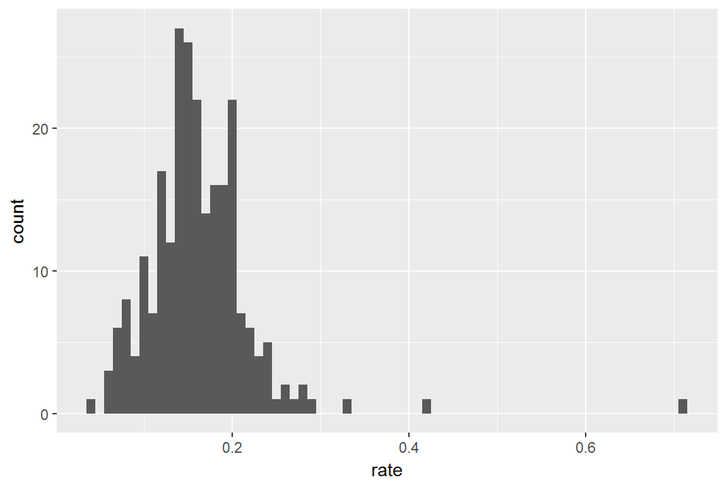

```r
qplot(x = rate, data = tips, binwidth = .01)
```

One person tipped over 70%, who are they?

```r
tips[which.max(tips$rate),]
##     total_bill  tip  sex smoker day   time size      rate
## 173       7.25 5.15 Male    Yes Sun Dinner    2 0.7103448
```

Calculate the average tipping rate for men and women separately:

```r
mean(tips$rate[tips$sex == "Male"])
## [1] 0.1576505
mean(tips$rate[tips$sex == "Female"])
## [1] 0.1664907
```

Is the difference between the two groups statistically significant? Calculate a t-test to examine whether the average tip rate for men is the same as the average tip rate for women.

```r
t.test(rate ~ sex, data = tips)
##
##  Welch Two Sample t-test
##
## data:  rate by sex
## t = 1.1433, df = 206.76, p-value = 0.2542
## alternative hypothesis: true difference in means is not equal to 0
## 95 percent confidence interval:
##  -0.006404119  0.024084498
## sample estimates:
## mean in group Female   mean in group Male
##            0.1664907            0.1576505
```

The p-value is greater than 0.05, and the confidence interval contains 0: there is no evidence of a significant difference in tipping rate between men and women.

Compare two groups using a side-by-side boxplot. For instance, do smokers tip at a different rate than non-smokers?

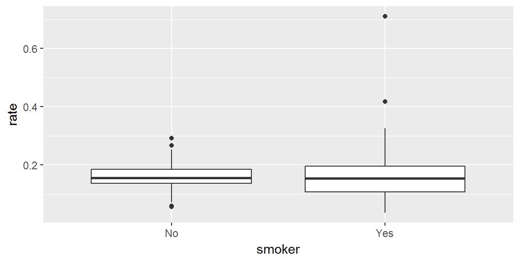

```r
qplot(x = smoker, y = rate, geom = "boxplot", data = tips)
```

##### Your Turn!

Try playing with chunks of code shown above to further investigate the tips data:

1. Get a summary of the total bill values
2. Make side by side boxplots of tip rates for different days of the week
3. Find the average tip value for smokers

##### Solutions

1. Get a summary of the total bill values

```r
summary(tips$total_bill)
##    Min. 1st Qu.  Median    Mean 3rd Qu.    Max.
##    3.07   13.35   17.80   19.79   24.13   50.81
```

2. Make side by side boxplots of tip rates for different days of the week

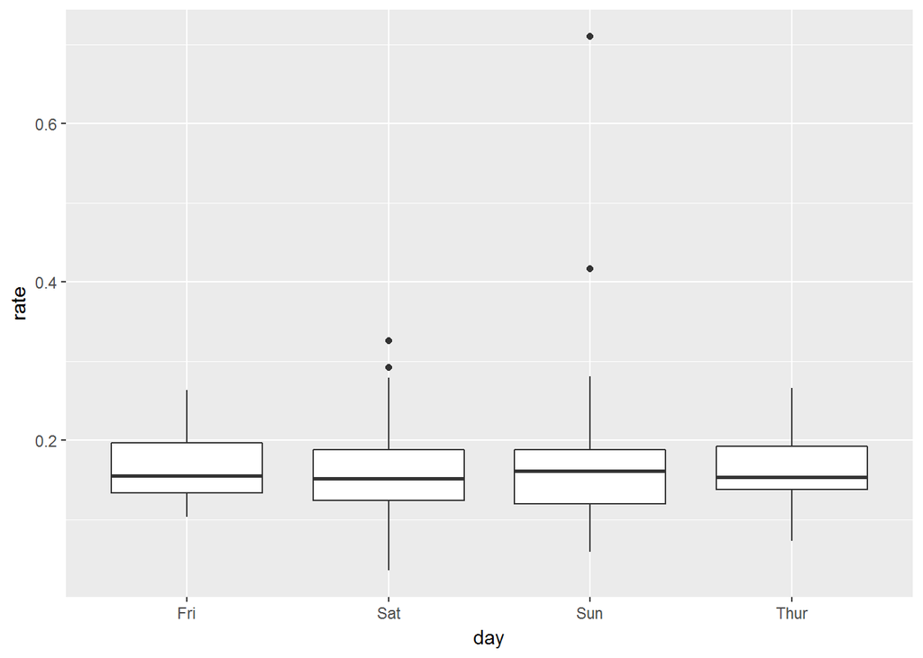

```r
qplot(day, rate, geom = "boxplot", data = tips)
```

3. Find the average tip value for smokers

```r
mean(tips$tip[tips$smoker == "Yes"])
## [1] 3.00871
```

# R Basics

## Getting Help in R

The `help()` function is useful for getting help with a function:

```r
help(head)
```

The `?` function also works:

```r
?head
```

When searching for results online, it is helpful to use R + CRAN + <query> to get good results.

## R Reference Card

A copy of the R reference card is available at:

http://cran.r-project.org/doc/contrib/Short-refcard.pdf

This card contains short versions of the most common functions used in R.

## R as an Overgrown Calculator

R can perform simple mathematical operations.

```r
# Addition and Subtraction
2 + 5 - 1
## [1] 6

# Multiplication
109*23452
## [1] 2556268

# Division
3/7
## [1] 0.4285714
```

Here are a few more complex operations:

```r
# Integer division
7 %/% 2
## [1] 3

# Modulo operator (Remainder)
7 %% 2
## [1] 1

# Powers
1.5 ^ 3
## [1] 3.375
```

```r
# Exponentiation
exp(3)
## [1] 20.08554

# Logarithms
log(3)
## [1] 1.098612
log(3, base = 10)
## [1] 0.4771213

# Trig functions
sin(0)
## [1] 0
cos(0)
## [1] 1
tan(pi/4)
## [1] 1

asin(0)
## [1] 0
acos(1)
## [1] 0
atan(1)
## [1] 0.7853982
```

## Variables in R

Variables in R are created using the assignment operator, `<-`:

```r
x <- 5
R_awesomeness <- Inf
MyAge <- 21 #Haha
```

These variables can then be used in computation:

```r
log(x)
## [1] 1.609438
MyAge ^ 2
## [1] 441
```

### Rules for Variable Names

- Variable names can’t start with a number
- Names are case-sensitive
- Common letters are used internally by R and should be avoided as variable names  
  `c, q, t, C, D, F, T, I`
- There are reserved words that R won’t allow as variable names.  
  `for, in, while, if, else, repeat, break, next`
- R will let you use the name of a predefined function.  
  Try not to overwrite those!

#### Error messages

```r
# Variable starts with a number
1age <- 3
## Error: <text>:2:2: unexpected symbol
## 1: # Variable starts with a number
## 2: 1age
##     ^
```

```r
# Case Sensitive
Age <- 3
age
## Error in eval(expr, envir, enclos): object 'age' not found
```

```r
# Special Words can't be variable names
for <- 3
## Error: <text>:2:5: unexpected assignment
## 1: # Special Words can't be variable names
## 2: for <-
##        ^
```

#### A Cautionary Tale

```r
# This is a VERY bad idea:

T <- FALSE
F <- TRUE

T == FALSE
## [1] TRUE
F == TRUE
## [1] TRUE

rm(T, F) # Fix it!

T == FALSE
## [1] FALSE
```

Note: In R, `T` and `F` are shorthand for `TRUE` and `FALSE` respectively.

## Vectors

A variable can contain more than one value.  
A *vector* is a variable which contains a set of values of the same type.  
The `c()` (combine) function is used to create vectors:

```r
y <- c(1, 5, 3, 2)
z <- c(y, y)
```

R performs operations on the entire vector at once:

```r
y / 2
## [1] 0.5 2.5 1.5 1.0
z + 3
## [1] 4 8 6 5 4 8 6 5
```

Vectors can be created using the `c()` or `rep()` function. To create a vector of consecutive values, use the `:` function:

```r
a <- 10:15
a
## [1] 10 11 12 13 14 15
```

### Modifying Vectors

Vectors can be modified using indexing:

```r
# Get the total bill out of the tips dataset
bill <- tips$total_bill

x <- bill[1:5]
x
## [1] 16.99 10.34 21.01 23.68 24.59
x[1] <- 20
x
## [1] 20.00 10.34 21.01 23.68 24.59
```

Elements of a vector must all be the same type:

```r
head(bill)
## [1] 16.99 10.34 21.01 23.68 24.59 25.29
bill[5] <- ":-("
head(bill)
## [1] "16.99" "10.34" "21.01" "23.68" ":-("   "25.29"
```

By changing a value to a string, all the other values were changed to strings as well.

##### Your Turn

Using the R Reference Card (and the Help pages, if needed), do the following:

1. Find out how many rows and columns the `iris’ data set has. Figure out at least 2 ways to do this.  
   *Hint: “Variable Information” section on the first page of the reference card!*
2. Use the `rep` function to construct the following vector: `1 1 2 2 3 3 4 4 5 5`  
   *Hint: “Data Creation” section of the reference card*
3. Use `rep` to construct this vector: `1 2 3 4 5 1 2 3 4 5 1 2 3 4 5`

##### Solutions

1. Find out how many rows and columns the `iris’ data set has. Figure out at least 2 ways to do this.

```r
data(iris)

# first way:
nrow(iris)
## [1] 150
ncol(iris)
## [1] 5

# second way:
dim(iris)
## [1] 150   5

# third way:
str(iris) # look at the top line
## 'data.frame':    150 obs. of  5 variables:
##  $ Sepal.Length: num  5.1 4.9 4.7 4.6 5 5.4 4.6 5 4.4 4.9 ...
##  $ Sepal.Width : num  3.5 3 3.2 3.1 3.6 3.9 3.4 3.4 2.9 3.1 ...
##  $ Petal.Length: num  1.4 1.4 1.3 1.5 1.4 1.7 1.4 1.5 1.4 1.5 ...
##  $ Petal.Width : num  0.2 0.2 0.2 0.2 0.2 0.4 0.3 0.2 0.2 0.1 ...
##  $ Species     : Factor w/ 3 levels "setosa","versicolor",..: 1 1 1 1 1 1 1 1 1 1 ...
```

2. Use the `rep` function to construct the following vector: 1 1 2 2 3 3 4 4 5 5

```r
rep(c(1:5), each = 2)
##  [1] 1 1 2 2 3 3 4 4 5 5
```

3. Use `rep` to construct this vector: 1 2 3 4 5 1 2 3 4 5 1 2 3 4 5

```r
rep(c(1:5), times = 3)
##  [1] 1 2 3 4 5 1 2 3 4 5 1 2 3 4 5
```

###### End Solutions

Vectors can be manipulated by indexing.

Different elements of a vector can be extracted using brackets:

```r
a[1]
## [1] 10
a[2]
## [1] 11
a[5]
## [1] 14
```

Indexes can also be more complicated:

```r
a[c(1, 3, 5)]
## [1] 10 12 14
a[1:5]
## [1] 10 11 12 13 14
```

## Logical Values

- R has built in support for logical values
- TRUE and FALSE are built in. T (for TRUE) and F (for FALSE) are supported but can be modified
- Logicals can result from a comparison using
  - $<$
  - $>$
  - $<=$
  - $>=$
  - $==$
  - $!=$

### Indexing with Logicals

Logical vectors can be used for indexing as well:

```r
x <- c(2, 3, 5, 7)
x[c(TRUE, FALSE, FALSE, TRUE)]
## [1] 2 7
x > 3.5
## [1] FALSE FALSE  TRUE  TRUE
x[x > 3.5]
## [1] 5 7
```

#### Examples

```r
# Get the rate variable out of the tips dataset
rate <- tips$rate

head(rate)
## [1] 0.05944673 0.16054159 0.16658734 0.13978041 0.14680765 0.18623962

sad_tip <- rate < 0.10

rate[sad_tip]
##  [1] 0.05944673 0.07180385 0.07892660 0.05679667 0.09935739 0.05643341
##  [7] 0.09553024 0.07861635 0.07296137 0.08146640 0.09984301 0.09452888
## [13] 0.07717751 0.07398274 0.06565988 0.09560229 0.09001406 0.07745933
## [19] 0.08364236 0.06653360 0.08527132 0.08329863 0.07936508 0.03563814
## [25] 0.07358352 0.08822232 0.09820426
```

## Data Frames

A collection of vectors, similar to a table in an Excel spreadsheet

- A data set is stored in a data frame
- Each column is a vector of the same length
- Each column can be a different type of data
- Each element in the vector/column has to have the same type of data
- columns can be accessed using `$`

`tips` is a data frame:

```r
head(tips)
##   total_bill  tip    sex smoker day   time size       rate
## 1      16.99 1.01 Female     No Sun Dinner    2 0.05944673
## 2      10.34 1.66   Male     No Sun Dinner    3 0.16054159
## 3      21.01 3.50   Male     No Sun Dinner    3 0.16658734
## 4      23.68 3.31   Male     No Sun Dinner    2 0.13978041
## 5      24.59 3.61 Female     No Sun Dinner    4 0.14680765
## 6      25.29 4.71   Male     No Sun Dinner    4 0.18623962
```

`tips$sex` shows the `sex` column of `tips`

```r
tips$sex[1:20]
##  [1] Female Male   Male   Male   Female Male   Male   Male   Male   Male
## [11] Male   Female Male   Male   Female Male   Female Male   Female Male
## Levels: Female Male
# Show the first 20 items in the sex column of tips
```

##### Your Turn

1. Find out how many people tipped over 20%.  
   *Hint: use the `sum` function on a logical vector to calculate how many TRUEs are in the vector:*

```r
sum(c(TRUE, TRUE, FALSE, TRUE, FALSE))
## [1] 3
```

2. **More Challenging**: Calculate the sum of the total bills of anyone who tipped over 20%

##### Solutions

1. How many people tipped over 20%?

```r
sum(tips$rate > .2)
## [1] 39
```

2. Sum of the total bills where the tip was over 20%

```r
sum(tips$total_bill[tips$rate > .2])
## [1] 619.23
```

###### End Solutions

## Data Types in R

- Can use `mode` or `class` to find out information about variables
- `str` is useful to find information about the structure of your data
- Many data types: numeric, integer, character, Date, and factor most common

```r
str(tips)
## 'data.frame':    244 obs. of  8 variables:
##  $ total_bill: num  17 10.3 21 23.7 24.6 ...
##  $ tip       : num  1.01 1.66 3.5 3.31 3.61 4.71 2 3.12 1.96 3.23 ...
##  $ sex       : Factor w/ 2 levels "Female","Male": 1 2 2 2 1 2 2 2 2 2 ...
##  $ smoker    : Factor w/ 2 levels "No","Yes": 1 1 1 1 1 1 1 1 1 1 ...
##  $ day       : Factor w/ 4 levels "Fri","Sat","Sun",..: 3 3 3 3 3 3 3 3 3 3 ...
##  $ time      : Factor w/ 2 levels "Dinner","Lunch": 1 1 1 1 1 1 1 1 1 1 ...
##  $ size      : int  2 3 3 2 4 4 2 4 2 2 ...
##  $ rate      : num  0.0594 0.1605 0.1666 0.1398 0.1468 ...
```

Use `mode` and `class` to get more general information:

```r
class(tips)
## [1] "data.frame"
mode(tips)
## [1] "list"
```

tips is a data frame, which is a list of vectors that have the same length.

### Converting Between Types

Convert variables to a different type using the `as` series of functions:

```r
size <- head(tips$size)
size
## [1] 2 3 3 2 4 4
as.character(size)
## [1] "2" "3" "3" "2" "4" "4"
as.numeric("2")
## [1] 2
```

## Some useful functions

There are a whole variety of useful functions to operate on vectors.

```r
tip <- tips$tip
x <- tip[1:5]
length(x) # Number of elements of a vector
## [1] 5
sum(x) # Sum of elements in a vector
## [1] 13.09
```

Using the basic functions it wouldn’t be hard to compute some basic statistics.

```r
# Homemade Statistical Functions
(n <- length(tip))
## [1] 244
(meantip <- sum(tip) / n)
## [1] 2.998279
(standdev <- sqrt(sum((tip - meantip)^2) / (n - 1)))
## [1] 1.383638
```

But these functions are already built in to R.

```r
# Built in statistical functions
mean(tip)
## [1] 2.998279
sd(tip)
## [1] 1.383638
summary(tip)
##    Min. 1st Qu.  Median    Mean 3rd Qu.    Max.
##   1.000   2.000   2.900   2.998   3.562  10.000
quantile(tip, c(.025, .975))
##   2.5%  97.5%
## 1.1760 6.4625
```

## Element-wise Logical Operators

- `&` (elementwise AND)
- `|` (elementwise OR)

```r
c(T, T, F, F) & c(T, F, T, F)
## [1]  TRUE FALSE FALSE FALSE
c(T, T, F, F) | c(T, F, T, F)
## [1]  TRUE  TRUE  TRUE FALSE
# Which are big bills with a poor tip rate?
id <- (bill > 40 & rate < .10)
tips[id,]
##     total_bill tip    sex smoker day   time size       rate
## 103      44.30 2.5 Female    Yes Sat Dinner    3 0.05643341
## 183      45.35 3.5   Male    Yes Sun Dinner    3 0.07717751
## 185      40.55 3.0   Male    Yes Sun Dinner    2 0.07398274
```

##### Your Turn

```r
data(diamonds)
```

1. Read up on the dataset (`?diamonds`)
2. Plot price by carat (use qplot - go back to the motivating example for help with the syntax)
3. Create a variable `ppc` for price/carat. Store this variable as a column in the diamonds data
4. Make a histogram of all ppc values that exceed $10000 per carat.
5. Explore any other interesting relationships you find

##### Solutions

2. Plot price by carat (use qplot - go back to the motivating example for help with the syntax)

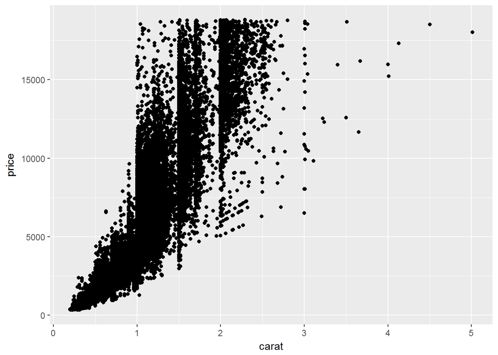

```r
qplot(carat, price, data = diamonds)
```

3. Create a variable `ppc` for price/carat. Store this variable as a column in the diamonds data

```r
diamonds$ppc <- diamonds$price / diamonds$carat
```

4. Make a histogram of all ppc values that exceed $10000 per carat.

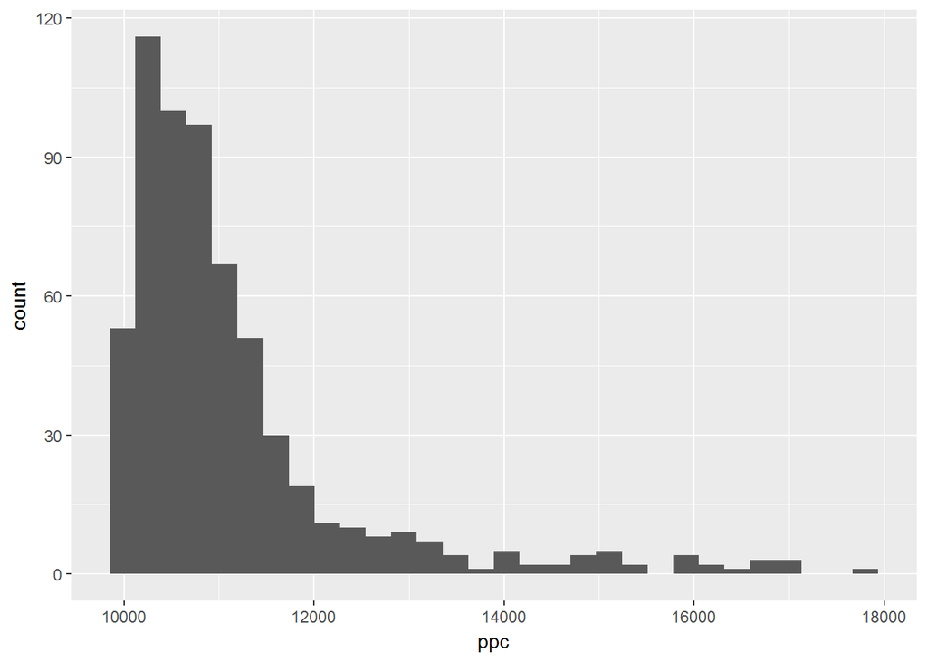

```r
qplot(ppc, geom = "histogram", data = diamonds[diamonds$ppc > 10000,])
## `stat_bin()` using `bins = 30`. Pick better value with `binwidth`.
```

5. Explore any other interesting relationships you find

# Data Structures

## Data Frames

- Data Frames are the work horse of R objects
- Structured by rows and columns and can be indexed
- Each column is a specified variable type
- Columns names can be used to index a variable
- Advice for naming variable applies to editing columns names
- Can be specified by grouping vectors of equal length as columns

Data frames can be indexed in several ways:

- Elements indexed similar to a vector using `[` `]`
- `df[i,j]` will select the element in the $i^{th}$ row and $j^{th}$ column
- `df[ ,j]` will select the entire $j^{th}$ column and treat it as a vector
- `df[i ,]` will select the entire $i^{th}$ row and treat it as a vector
- Logical vectors can be used in place of i and j used to subset the row and columns

New variables can be added to a data frame: 1. Create a new vector that is the same length as other columns 2. Append new column to the data frame using the `$` operator 3. The new data frame column will adopt the name of the vector

### Example

The following demonstration will use Edgar Anderson’s Iris Data:

```r
flower <- iris
```

Select Species column (5th column):

```r
head(flower[,5])
## [1] setosa setosa setosa setosa setosa setosa
## Levels: setosa versicolor virginica
```

Select Species column with the `$` operator:

```r
head(flower$Species)
## [1] setosa setosa setosa setosa setosa setosa
## Levels: setosa versicolor virginica
```

Logical indexing:

```r
head(flower$Species == "setosa")
## [1] TRUE TRUE TRUE TRUE TRUE TRUE

head(flower[flower$Species=="setosa", ])
##   Sepal.Length Sepal.Width Petal.Length Petal.Width Species
## 1          5.1         3.5          1.4         0.2  setosa
## 2          4.9         3.0          1.4         0.2  setosa
## 3          4.7         3.2          1.3         0.2  setosa
## 4          4.6         3.1          1.5         0.2  setosa
## 5          5.0         3.6          1.4         0.2  setosa
## 6          5.4         3.9          1.7         0.4  setosa
```

### Creating a Data Frame

Create a data frame using `data.frame` function

```r
mydf <- data.frame(NUMS = 1:5,
                   lets = letters[1:5],
                   vehicle = c("car", "boat", "car", "car", "boat"))
mydf
##   NUMS lets vehicle
## 1    1    a     car
## 2    2    b    boat
## 3    3    c     car
## 4    4    d     car
## 5    5    e    boat
```

Column names can be accessed with the `names` function. They can also be changed by assigning values to `names(df)`, as shown below.

```r
# Use the `names` function to set that first column to lowercase:
names(mydf)[1] <- "nums"
mydf
##   nums lets vehicle
## 1    1    a     car
## 2    2    b    boat
## 3    3    c     car
## 4    4    d     car
## 5    5    e    boat
```

##### Your Turn

1. Make a data frame with column 1: 1,2,3,4,5,6 and column 2: a,b,a,b,a,b
2. Select only rows with value “a” in column 2 using logical vector
3. `mtcars` is a built in data set like `iris`: Extract the 4th row of the `mtcars` data.

##### Solutions

1. Make a data frame with column 1: 1,2,3,4,5,6 and column 2: a,b,a,b,a,b

```r
mydf <- data.frame(col1 = 1:6, col2 = rep(c("a", "b"), times = 3))

mydf
##   col1 col2
## 1    1    a
## 2    2    b
## 3    3    a
## 4    4    b
## 5    5    a
## 6    6    b
```

2. Select only rows with value “a” in column 2 using logical vector

```r
mydf[mydf$col2 == "a",]
##   col1 col2
## 1    1    a
## 3    3    a
## 5    5    a
```

3. Extract the 4th row of the `mtcars` data.

```r
data(mtcars)

mtcars[4,]
##                 mpg cyl disp  hp drat    wt  qsec vs am gear carb
## Hornet 4 Drive 21.4   6  258 110 3.08 3.215 19.44  1  0    3    1
```

###### End Solutions

## Lists

- Lists are a structured collection of R objects
- R objects in a list need not be the same type
- Create lists using the `list` function
- Lists indexed using double square brackets `[[ ]]` to select an object

### Example

Create a list containing a matrix and a vector:

```r
mylist <- list(matrix(letters[1:10], nrow = 2, ncol = 5),
               seq(0, 49, by = 7))
mylist
## [[1]]
##      [,1] [,2] [,3] [,4] [,5]
## [1,] "a"  "c"  "e"  "g"  "i"
## [2,] "b"  "d"  "f"  "h"  "j"
##
## [[2]]
## [1]  0  7 14 21 28 35 42 49
```

Use indexing to select the second list element:

```r
mylist[[2]]
## [1]  0  7 14 21 28 35 42 49
```

##### Your Turn

1. Create a list containing a vector and a 2x3 data frame
2. Use indexing to select the data frame from your list
3. Use further indexing to select the first row from the data frame in your list

##### Solutions

1. Create a list containing a vector and a 2x3 data frame

```r
mylist <- list(vec = 1:6, df = data.frame(x = 1:2, y = 3:4, z = 5:6))
```

2. Use indexing to select the data frame from your list

```r
mylist[[2]]
##   x y z
## 1 1 3 5
## 2 2 4 6
```

3. Select the first row from the data frame in your list

```r
mylist[[2]][1,]
##   x y z
## 1 1 3 5
```

###### End Solutions

## Examining Objects

R objects can get very complicated very quickly (nesting lists inside of lists, for example). The following functions are useful to figure out the structure of objects in R.

- `head(x)` - View top 6 rows of a data frame
- `tail(x)` - View bottom 6 rows of a data frame
- `summary(x)` - Summary statistics
- `str(x)` - View structure of object
- `dim(x)` - View dimensions of object
- `length(x)` - Returns the length of a vector